# P3 - Behavioral cloning

```python
%matplotlib inline
import matplotlib.pyplot as plt
import matplotlib.image as mpimg
import os
import cv2
import numpy as np
import pandas as pd
```

```python
##
# Global vars
#
steering_range = 0.36
```

## Data reading

The procedure fo data reading was designed to easily throw new recordings and enable or disable without the need to change the code (Every directory used for training should contain the word 'enabled' in its name).

```python
##
# Read the recorded data and create a shuffled dataset
#
rec_dir = 'data'
recording_dirs = [os.path.join(rec_dir, name) for name in os.listdir(rec_dir) if os.path.isdir(os.path.join(rec_dir, name)) and 'enabled' in name]

header = ['center_image', 'left_image', 'right_image', 'steering_angle', 'throttle', 'break', 'speed']

header_dict = {'center_image': 0,
               'left_image': 1,
               'right_image': 2,
               'steering_angle': 3,
               'throttle': 4,
               'break': 5,
               'speed': 6}

dataset = pd.DataFrame()

# Process every directory and read the data in it
for d in recording_dirs:
    print('Processing {}'.format(d))
    tmp = pd.read_csv(os.path.join(d, 'driving_log.csv'), header=None, names=header, comment='#')
    tmp.left_image = d + os.path.sep + tmp.left_image.str.strip()
    tmp.center_image = d + os.path.sep + tmp.center_image.str.strip()
    tmp.right_image = d + os.path.sep + tmp.right_image.str.strip()
    dataset = pd.concat([dataset, tmp])

# Reset index to avoid duplicated index (different files starts with 0 index)
dataset.reset_index(inplace=True, drop=True)
```

```
Processing data/udacity-enabled
```

## Data visualization

Here he can see how to data looks like. Some remarkable findinds:

- The majority of the recorded data is at full speed
- Also it wasn't recorded while breaking
- The distribution of angles is kind of normal, with a high peak at 0 angles (which corresponds with the track, where are lots of straight sections)

```python
##
# Display some info about the data
#
def plot_values(dataset):
    # Histogram of throttle
    fig = dataset.throttle.hist(bins=20)
    fig.set_title('Throttle')
    plt.show()

    # Histogram of speed
    fig = dataset.speed.hist(bins=20)
    fig.set_title('Speed')
    plt.show()

    # Histogram of break
    fig = dataset['break'].hist(bins=20)
    fig.set_title('Break')
    plt.show()

    # Histogram of steering angle
    fig = dataset.steering_angle.hist(bins=20)
    fig.set_title('Steering Angle')
    plt.show()

    # Plot of steering angle
    fig = dataset.steering_angle.plot()
    fig.set_title('Steering angle')
    plt.ylim(-2, 2)
    plt.show()
```

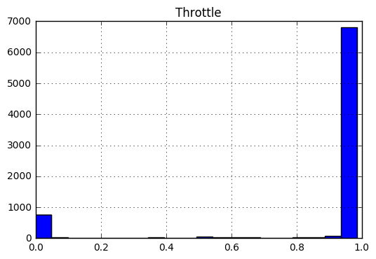

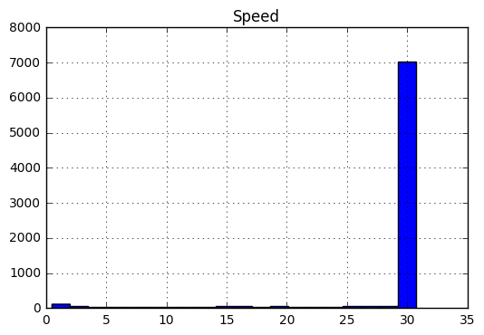

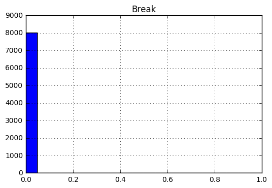

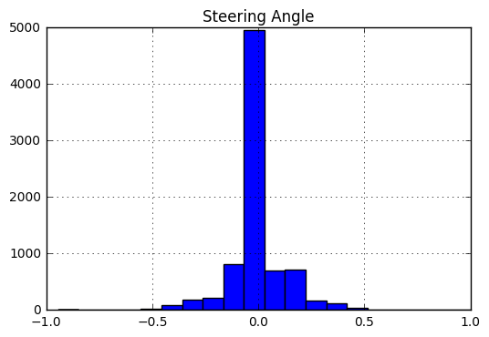

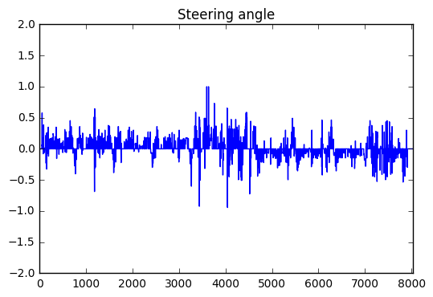

```python
plot_values(dataset)
```

To improve the quality of the data, speed below 25mph is discarded and also where breaks is higher than 0.1

```python
##
# Filter unwanted data
#

# Low speed (initial images, crashes, etc)
dataset = dataset[dataset.speed > 25]

# Hard breaking (dangerous situations, going off the road, etc.)
dataset = dataset[dataset['break'] < 0.1]
```

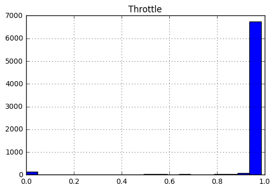

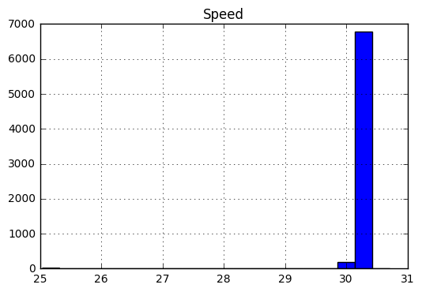

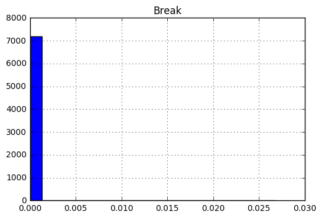

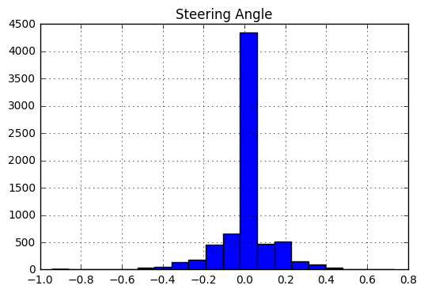

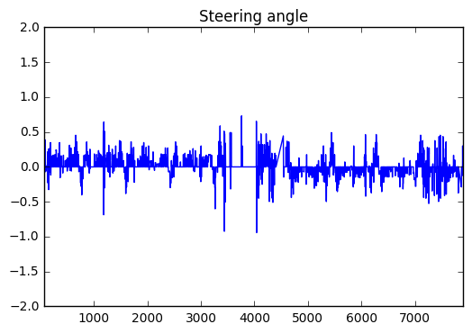

```python
plot_values(dataset)
```

The information used to predict the steering angle is the input from the from cameras. Here some samples of left, straight and right turn are displayed to have a better understanding of data:

[figure not shown]

[figure not shown]

[figure not shown]

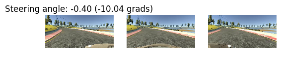

[figure not shown]

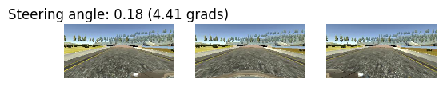

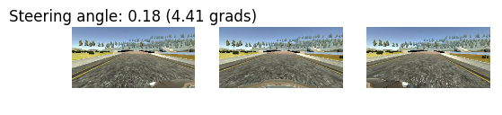

[figure not shown]

[figure not shown]

[figure not shown]

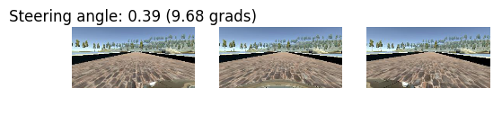

[figure not shown]

[3 more figures not shown]

```python
##
# Plot some images to visualize the data
#
# Number of images to plot
n_plot = 5

below = dataset.steering_angle < -steering_range
above = dataset.steering_angle > steering_range
zero = ~(below | above)

for ds in [dataset[below], dataset[zero], dataset[above]]:
    for i in range(n_plot):
            fig1 = plt.subplot(131)
            fig1.set_title('Steering angle: {:.2f} ({:.2f} grads)'.format(ds.iloc[i].steering_angle, ds.iloc[i].steering_angle*25))
            fig1.set_axis_off()
            image = mpimg.imread(str.strip(ds.iloc[i].left_image))
            fig1.imshow(image)

            fig2 = plt.subplot(132)
            fig2.set_axis_off()
            image = mpimg.imread(ds.iloc[i].center_image)
            fig2.imshow(image)

            fig3 = plt.subplot(133)
            fig3.set_axis_off()
            image = mpimg.imread(str.strip(ds.iloc[i].right_image))
            fig3.imshow(image)

            plt.show()
```

```
This image is: <class 'numpy.ndarray'> with dimesions: (160, 320, 3)
```

[figure not shown]

```python
# Reading in an image
image = mpimg.imread(os.path.join(rec_dir, 'image_example_track1.jpg'))
print('This image is:', type(image), 'with dimesions:', image.shape)

plt.imshow(image)
plt.show()
```

Some parts of the image are not useful (like the sky and the front of the car). After cutting those sections, the image is resampled in a 32x32 size see if it's possible to distinct where the car should steer to.

```
Drivable shape (70, 320, 3)
```

[figure not shown]

```python
low_l = int(0.3125 * image.shape[0])
sup_l = int(0.75 * image.shape[0])
img = image[low_l:sup_l,:]

drivable_shape = img.shape
print('Drivable shape {}'.format(drivable_shape))
plt.imshow(img)
plt.show()
```

Since we'll use a LeNet architecture, a 32x32 image is displayed.

We can appretiate that 32x32 conserves the information needed to distinguish the curvature of the road and it's much smaller (will train faster)

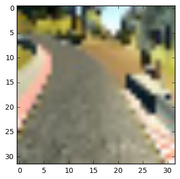

```python
lenet_shape = (32, 32)

plt.imshow(cv2.resize(img, lenet_shape))
plt.show()
```